# White Wine Quality Analysis - Divya Chandramouli

### Loading data

Load the data and print the names of variables in the dataset

```
##  [1] "X"                    "fixed.acidity"        "volatile.acidity"
##  [4] "citric.acid"          "residual.sugar"       "chlorides"
##  [7] "free.sulfur.dioxide"  "total.sulfur.dioxide" "density"
## [10] "pH"                   "sulphates"            "alcohol"
## [13] "quality"
```

### Introduction to the dataset

This dataset contains data on white variants of the Portuguese “Vinho Verde” wine. There are 11 variables quantifying the chemical properties of each wine. At least 3 wine experts rated the quality of each wine, providing a rating between 0 (very bad) and 10 (very excellent).This dataset is publicly available for research.

Citation: P. Cortez, A. Cerdeira, F. Almeida, T. Matos and J. Reis. Modeling wine preferences by data mining from physicochemical properties. In Decision Support Systems, Elsevier, 47(4):547-553. ISSN: 0167-9236.

The inputs include objective tests (e.g. PH values) and the output is based on sensory data (median of at least 3 evaluations made by wine experts).

### Description of Attributes

1. Fixed acidity: most acids involved with wine or fixed or nonvolatile (do not evaporate readily)
2. Volatile acidity: the amount of acetic acid in wine, which at too high of levels can lead to an unpleasant, vinegar taste
3. Citric acid: found in small quantities, citric acid can add ‘freshness’ and flavor to wines
4. Residual sugar: the amount of sugar remaining after fermentation stops, it’s rare to find wines with less than 1 gram/liter and wines with greater than 45 grams/liter are considered sweet
5. Chlorides: the amount of salt in the wine
6. Free sulfur dioxide: the free form of SO2 exists in equilibrium between molecular SO2 (as a dissolved gas) and bisulfite ion; it prevents microbial growth and the oxidation of wine
7. Total sulfur dioxide: amount of free and bound forms of S02; in low concentrations, SO2 is mostly undetectable in wine, but at free SO2 concentrations over 50 ppm, SO2 becomes evident in the nose and taste of wine
8. Density: the density of water is close to that of water depending on the percent alcohol and sugar content
9. pH: describes how acidic or basic a wine is on a scale from 0 (very acidic) to 14 (very basic); most wines are between 3-4 on the pH scale
10. Sulphates: a wine additive which can contribute to sulfur dioxide gas (S02) levels, wich acts as an antimicrobial and antioxidant
11. Alcohol: the percent alcohol content of the wine
12. Quality (score between 0 and 10) - Output variable (based on sensory data)

### Research Question

This project investigates which chemical properties influence the quality of white wines

### Understanding the dataset

In this section, we will perform some preliminary exploration of the dataset- Running some summaries of the data and creating univariate plots to understand the structure of the individual variables in the dataset.

#### Structure of the dataset

```
## [1] 4898   13
```

We have 4898 rows and 13 variables in the dataset - 11 physicochemical properties, 1 quality rating and 1 index/serial number

Let’s examine the structure of the dataframe, the variables and the type of data they hold

```
## 'data.frame':    4898 obs. of  13 variables:
##  $ X                   : int  1 2 3 4 5 6 7 8 9 10 ...
##  $ fixed.acidity       : num  7 6.3 8.1 7.2 7.2 8.1 6.2 7 6.3 8.1 ...
##  $ volatile.acidity    : num  0.27 0.3 0.28 0.23 0.23 0.28 0.32 0.27 0.3 0.22 ...
##  $ citric.acid         : num  0.36 0.34 0.4 0.32 0.32 0.4 0.16 0.36 0.34 0.43 ...
##  $ residual.sugar      : num  20.7 1.6 6.9 8.5 8.5 6.9 7 20.7 1.6 1.5 ...
##  $ chlorides           : num  0.045 0.049 0.05 0.058 0.058 0.05 0.045 0.045 0.049 0.044 ...
##  $ free.sulfur.dioxide : num  45 14 30 47 47 30 30 45 14 28 ...
##  $ total.sulfur.dioxide: num  170 132 97 186 186 97 136 170 132 129 ...
##  $ density             : num  1.001 0.994 0.995 0.996 0.996 ...
##  $ pH                  : num  3 3.3 3.26 3.19 3.19 3.26 3.18 3 3.3 3.22 ...
##  $ sulphates           : num  0.45 0.49 0.44 0.4 0.4 0.44 0.47 0.45 0.49 0.45 ...
##  $ alcohol             : num  8.8 9.5 10.1 9.9 9.9 10.1 9.6 8.8 9.5 11 ...
##  $ quality             : int  6 6 6 6 6 6 6 6 6 6 ...
```

#### Summary of the dataset

```
##        X        fixed.acidity    volatile.acidity  citric.acid
##  Min.   :   1   Min.   : 3.800   Min.   :0.0800   Min.   :0.0000
##  1st Qu.:1225   1st Qu.: 6.300   1st Qu.:0.2100   1st Qu.:0.2700
##  Median :2450   Median : 6.800   Median :0.2600   Median :0.3200
##  Mean   :2450   Mean   : 6.855   Mean   :0.2782   Mean   :0.3342
##  3rd Qu.:3674   3rd Qu.: 7.300   3rd Qu.:0.3200   3rd Qu.:0.3900
##  Max.   :4898   Max.   :14.200   Max.   :1.1000   Max.   :1.6600
##  residual.sugar     chlorides       free.sulfur.dioxide
##  Min.   : 0.600   Min.   :0.00900   Min.   :  2.00
##  1st Qu.: 1.700   1st Qu.:0.03600   1st Qu.: 23.00
##  Median : 5.200   Median :0.04300   Median : 34.00
##  Mean   : 6.391   Mean   :0.04577   Mean   : 35.31
##  3rd Qu.: 9.900   3rd Qu.:0.05000   3rd Qu.: 46.00
##  Max.   :65.800   Max.   :0.34600   Max.   :289.00
##  total.sulfur.dioxide    density             pH          sulphates
##  Min.   :  9.0        Min.   :0.9871   Min.   :2.720   Min.   :0.2200
##  1st Qu.:108.0        1st Qu.:0.9917   1st Qu.:3.090   1st Qu.:0.4100
##  Median :134.0        Median :0.9937   Median :3.180   Median :0.4700
##  Mean   :138.4        Mean   :0.9940   Mean   :3.188   Mean   :0.4898
##  3rd Qu.:167.0        3rd Qu.:0.9961   3rd Qu.:3.280   3rd Qu.:0.5500
##  Max.   :440.0        Max.   :1.0390   Max.   :3.820   Max.   :1.0800
##     alcohol         quality
##  Min.   : 8.00   Min.   :3.000
##  1st Qu.: 9.50   1st Qu.:5.000
##  Median :10.40   Median :6.000
##  Mean   :10.51   Mean   :5.878
##  3rd Qu.:11.40   3rd Qu.:6.000
##  Max.   :14.20   Max.   :9.000
```

#### Check for missing or null values in the dataset

```
## [1] FALSE
```

We do not any have missing values in the dataset

#### Are there duplicate records in the dataset?

```
## [1] 0
```

No, the dataset does not have duplicate records

### Univariate exploration

#### Fixed acidity

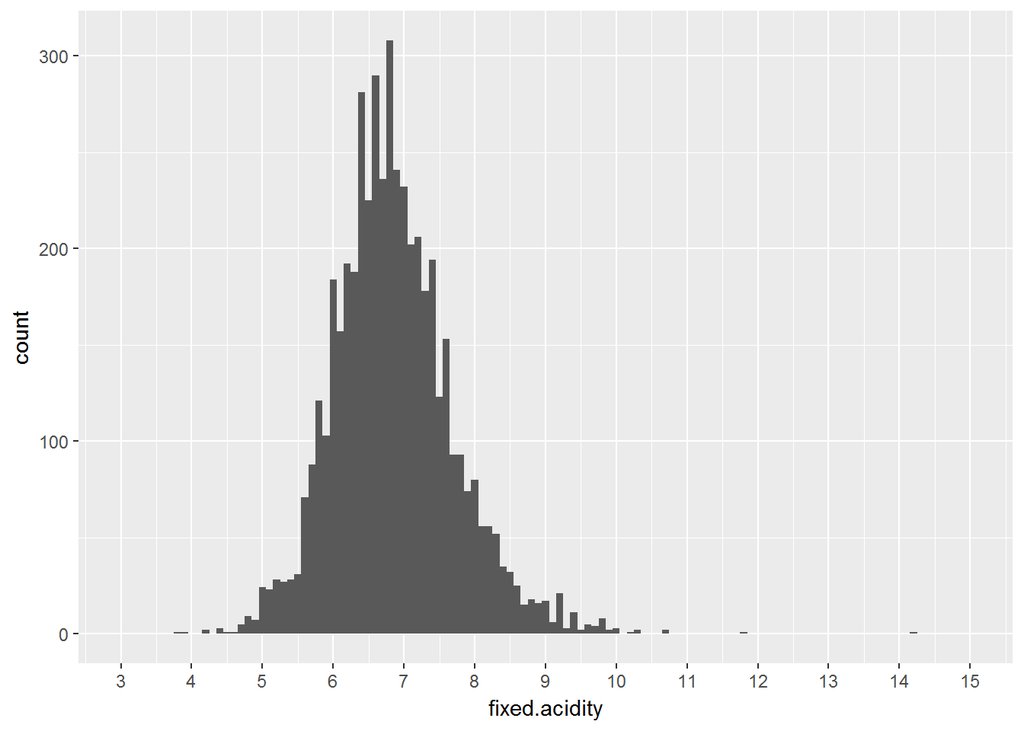

The distribution of fixed acidity looks like the bell curve and appears to be normally distributed. The range of fixed acidity is from 3.8 to 14.2 from the summary table. In the plot we can clearly see that the fixed acidity values for the bulk of wines lies between 4 and 10 with outliers on the right. 6.8 is the most commonly occurring value of fixed acidity

#### Volatile acidity

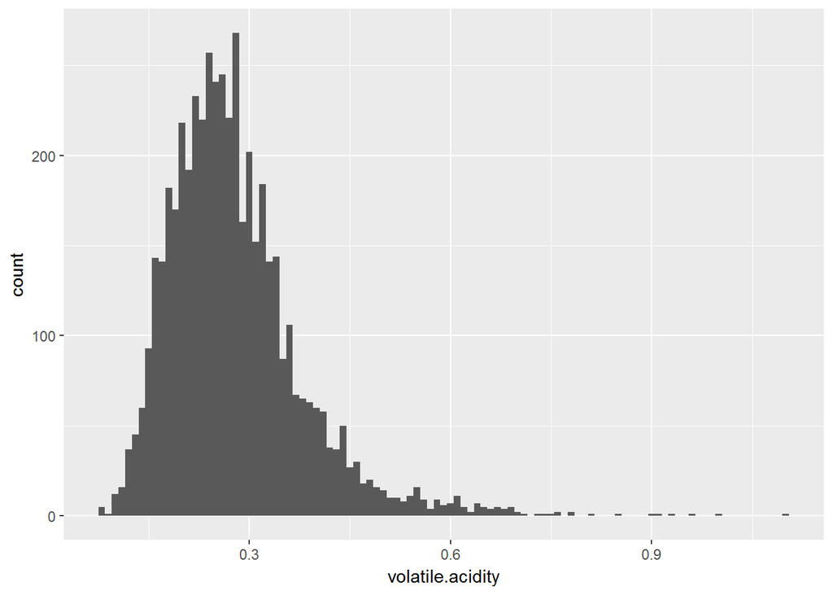

The distribution of volatile acidity looks skewed to the right. Most common value of volatile acidity is 0.28. Bulk of the wines have volatile acidity value under 0.6.

Since the distribution is skewed to the right, let us try a log10 transform

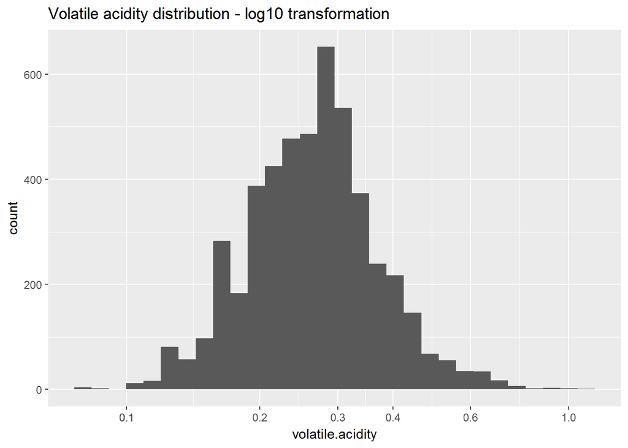

Now the distribution looks closer to the bell curve of normal distribution

#### Citric acid

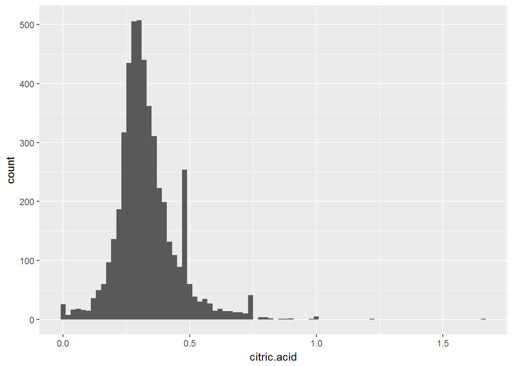

Bulk of the citric acid data looks normally distributed. There is an outlier with the value 1.66

#### Residual sugar

```
##    Min. 1st Qu.  Median    Mean 3rd Qu.    Max.
##   0.600   1.700   5.200   6.391   9.900  65.800
```

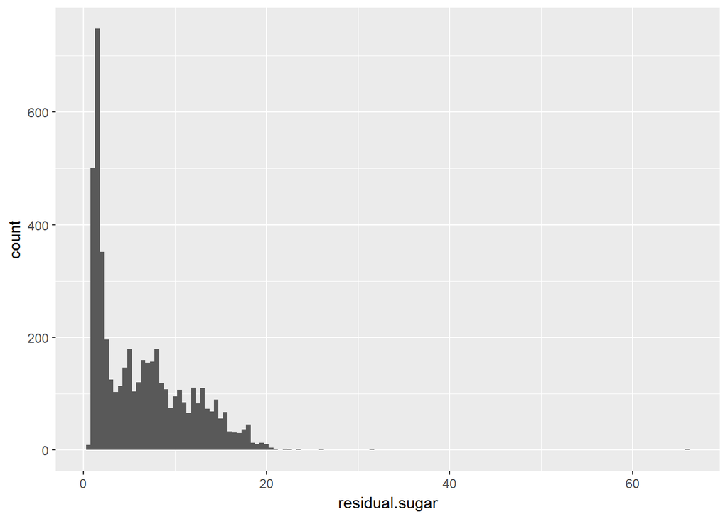

The distribution of residual sugar looks clearly skewed to the right with the maxvalue of 65.8 being an outlier

Let’s try a log10 transform on the data

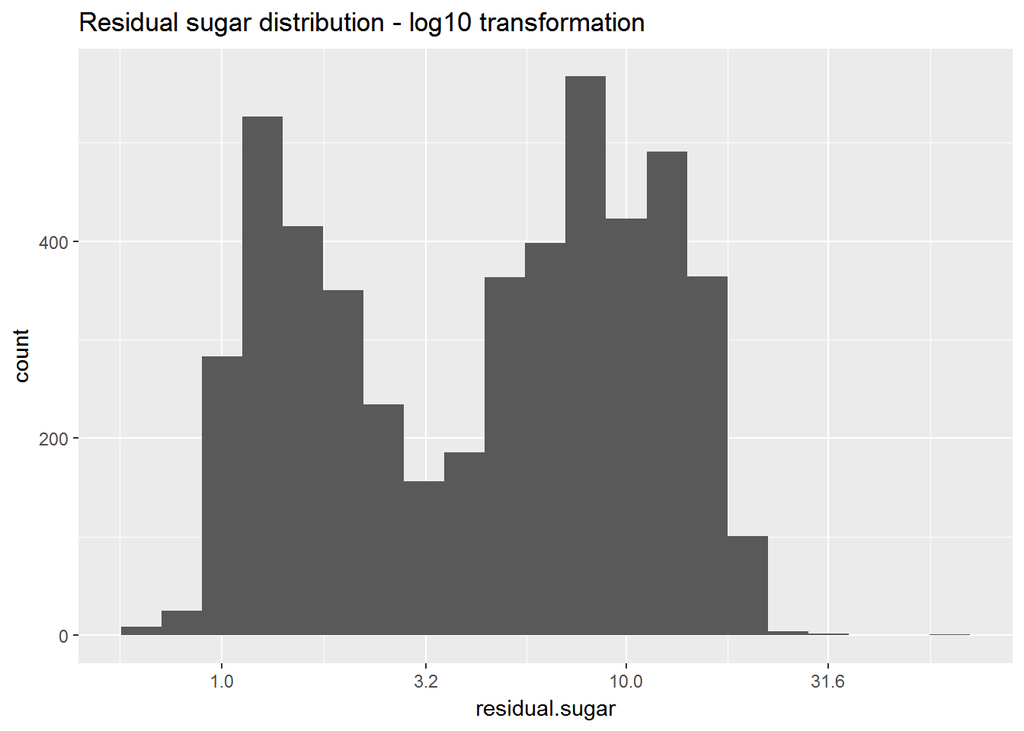

Now the distribution looks bimodal with peaks at about 1 and 9 values of residual sugar

If we trim the top 1% of residual sugar data, let’s see how the distribution looks

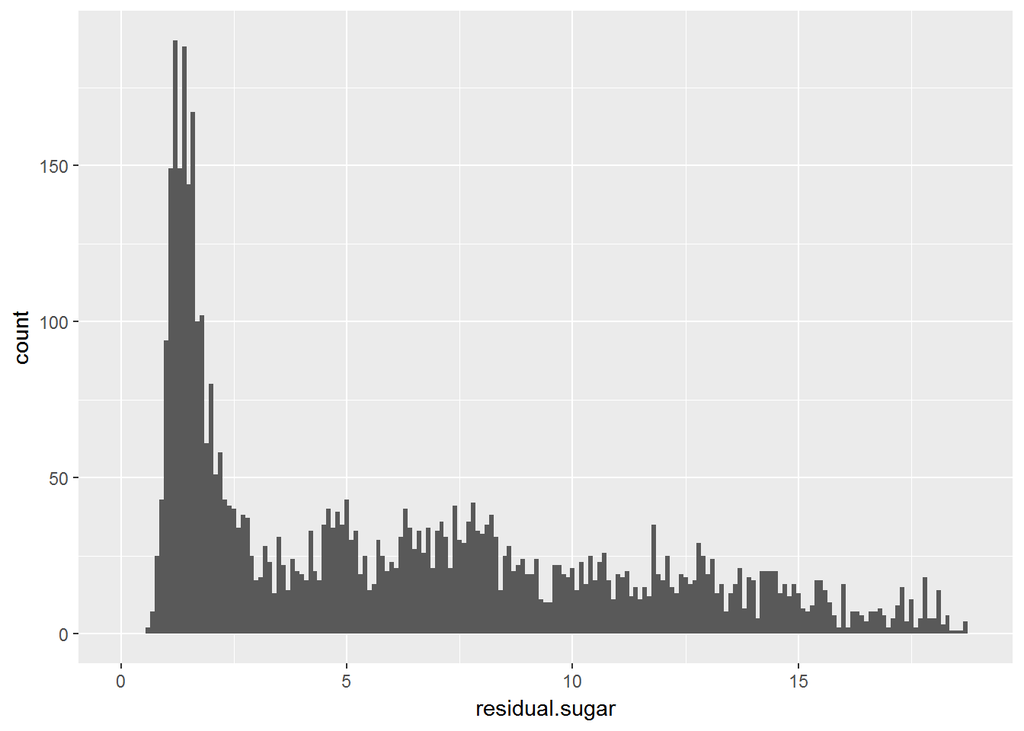

The distribution is still skewed to the right after trimming the top 1% of data

#### Chlorides

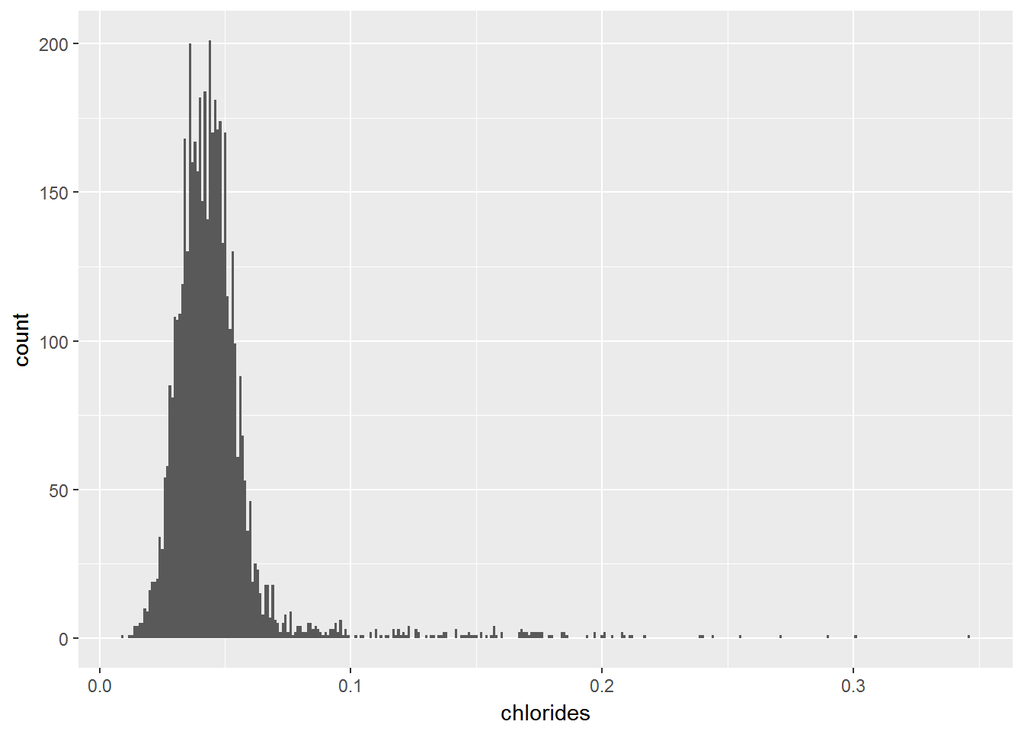

The distribution of chloride values looks skewed to the right with a thin and long tail on the right

Let us trim the top 3% of chloride values and see how our data looks

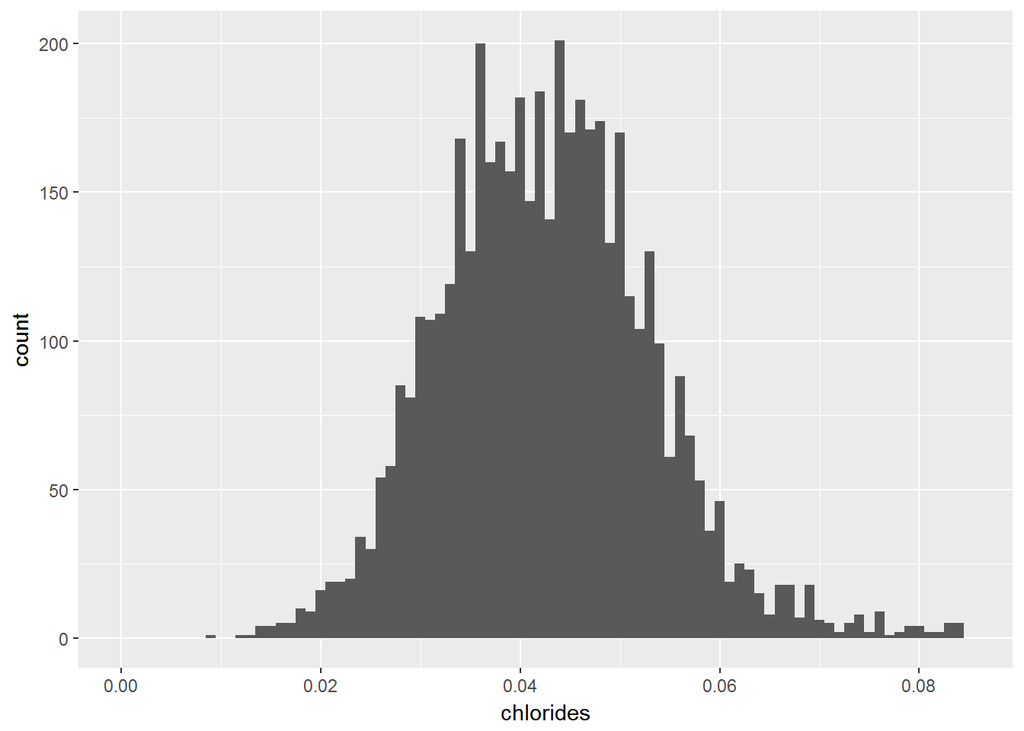

Now the data looks a little closer to normal distribution. But it might not be a good idea to lose 3% of the data

#### Free Sulphur dioxide

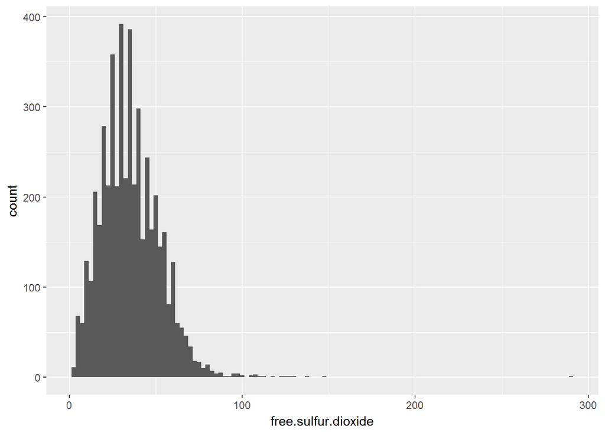

The distribution of free sulphurdioxide looks skewed to the right with an outlier point at 289

#### Total Sulphur dioxide

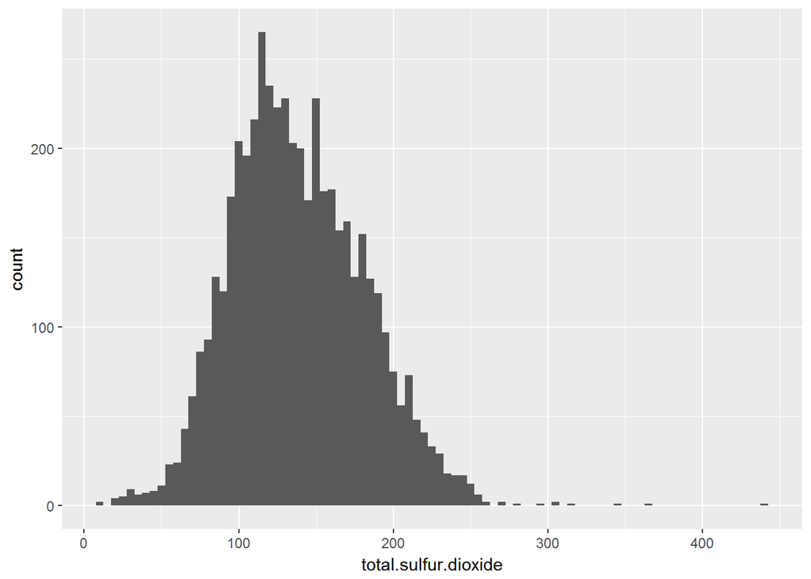

The bulk of total sulphur dioxide data looks normally distributed with a few outliers on the right

#### Density

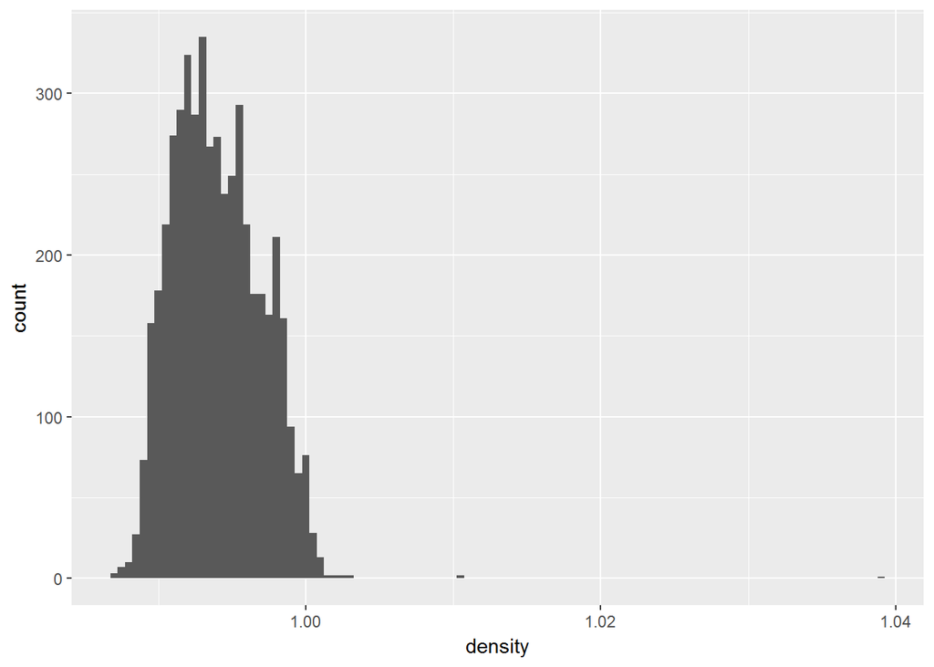

The distribution of density looks almost normally distributed Few wines seem to have a density greater than 1 - most probably they should be outliers

#### pH

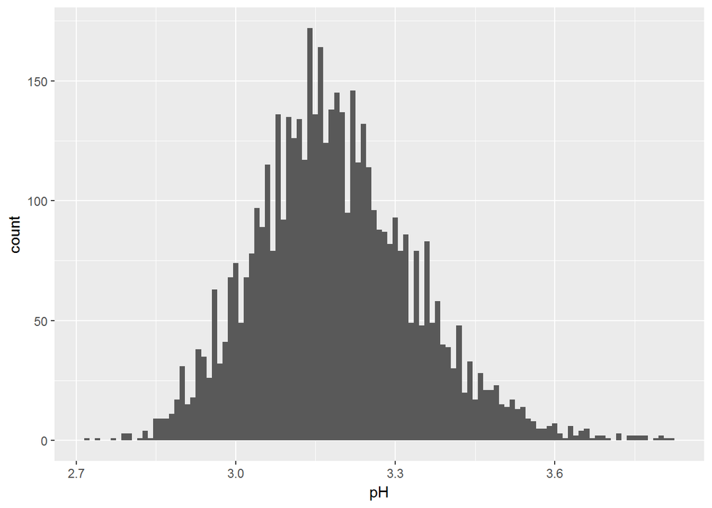

pH values appear to be normally distributed. From domain knowledge, we can expect pH / acidity to be key factors influencing the quality of wine

#### Sulphates

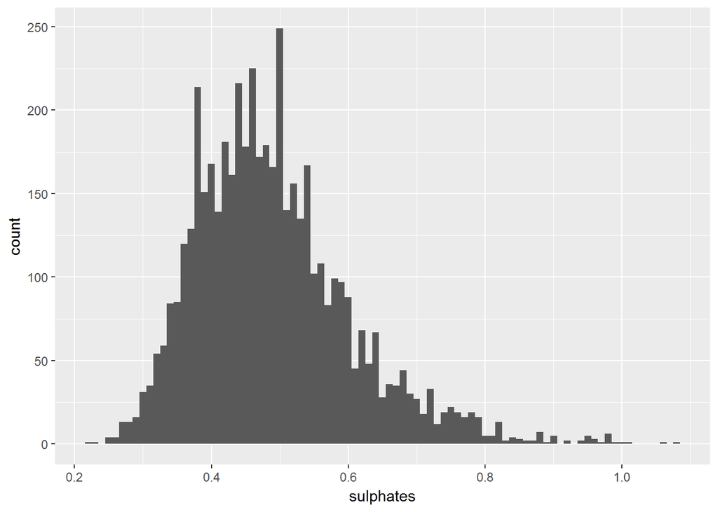

The distribution of sulphates appears skewed to the right

Let us transform the sulphates axis on a log10 scale

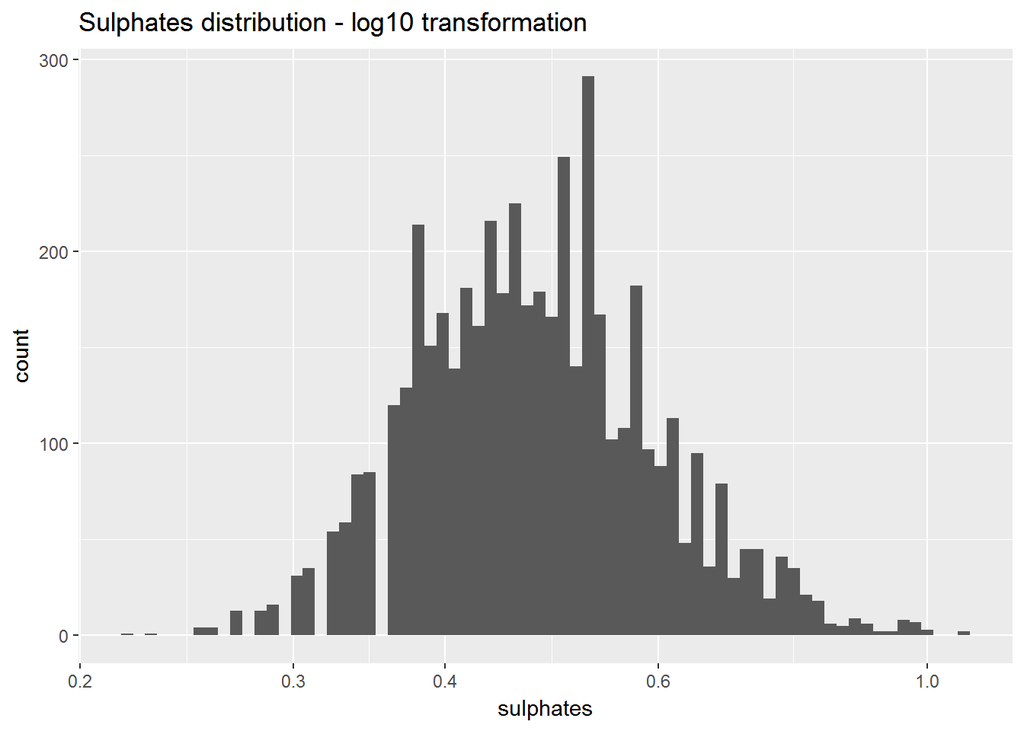

The distribution of sulphates appears closer to normal distribution with a log10 transformation

#### Alcohol

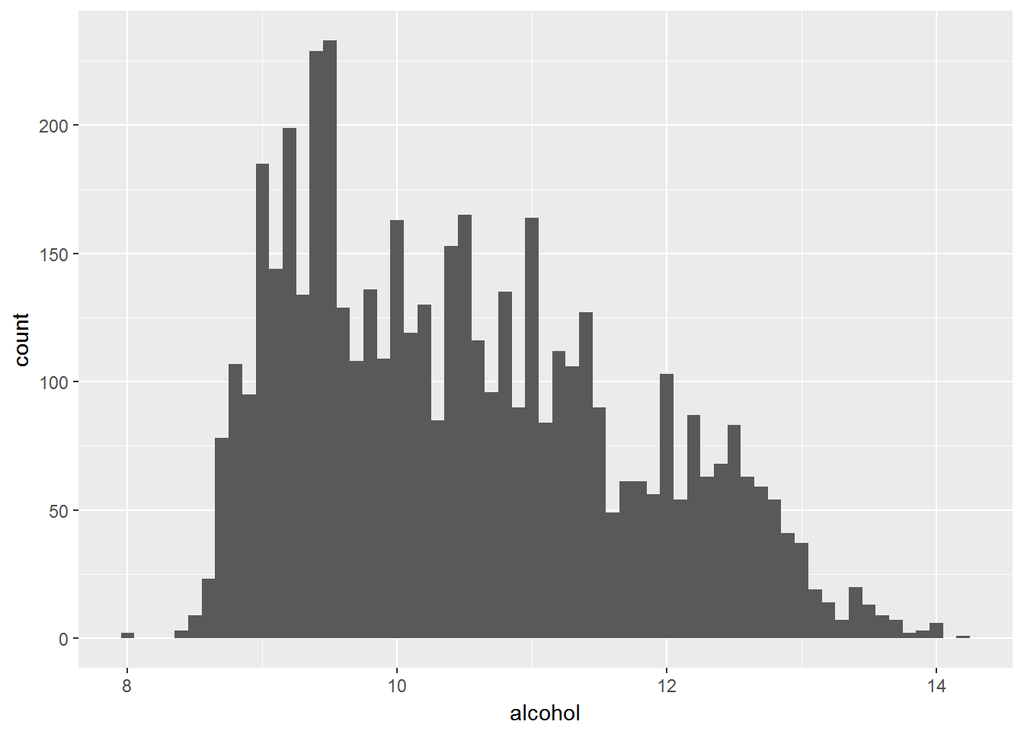

The histogram for alcohol level does not look normally distributed.

Let us try a log10 transform on alcohol level data

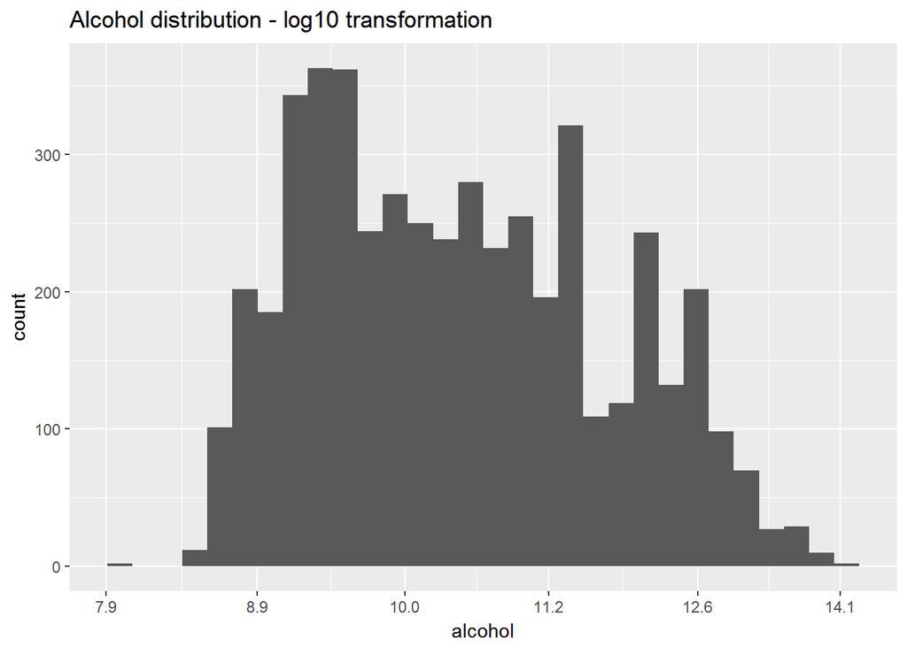

Even after the log10 transformation, alcohol level data does not look normally distributed

Let us try a sqrt transform on the alcohol level data

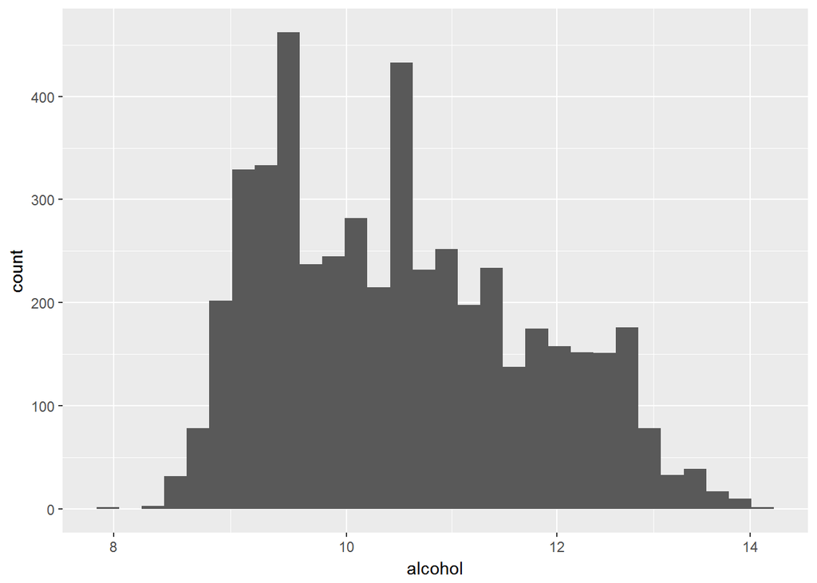

The sqrt transformation also doesn’t seem to make the alcohol level data normally distributed

From common knowledge, alcohol levels of wine could be a key influencer of wine quality

#### Quality

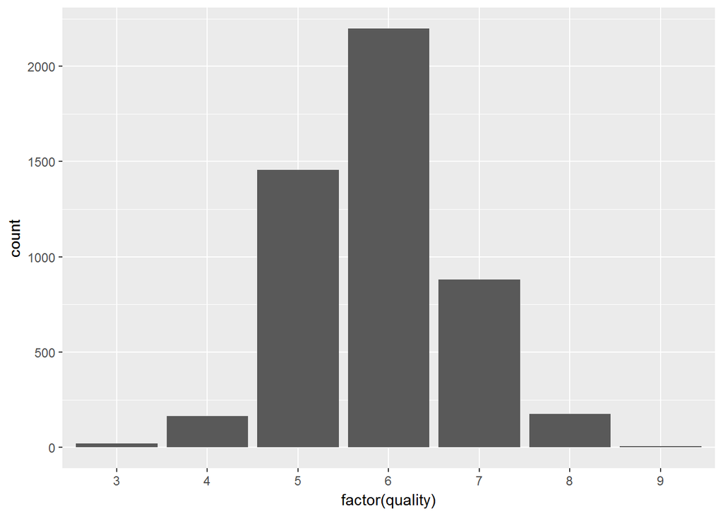

From the quality rating histogram, we can see that the bulk of wines have been rated 6, and only 5 wines have received a quality rating of 9, which is the best

The histogram consists of discrete bars at 3,4,5,6,7,8 and 9.

### Univariate Analysis

#### What is the structure of your dataset?

The dataset contains 4898 rows/observations with 13 variables/columns eleven of the columns represent physicochemical properties of wines and hold numerical values, one of the columns is the index/ID of each row which is an integer and one of the columns holds the quality rating for the wine which is also an integer

#### What is/are the main feature(s) of interest in your dataset?

The goal of this project is to investigate the influence of the physicochemical properties on the quality of wine. Therefore, quality rating is one of the main features of interest along with some other properties.

#### What other features in the dataset do you think will help support your investigation into your feature(s) of interest?

Since quality rating is from sensory data, residual sugar and pH could affect the sweetness/taste of wine and alcohol content could affect the experience of wine consumption. But the investigation will look at all the properties in the dataset

#### Did you create any new variables from existing variables in the dataset?

No, from just univariate exploration, it could not be ascertained if new variables need to be created.It will be looked at if further exploration gives rise to the need for creating more variables

#### Of the features you investigated, were there any unusual distributions? Did you perform any operations on the data to tidy, adjust, or change the form of the data? If so, why did you do this?

The data was assessed for missing or duplicate values. It appeared fairly tidy and prepared for analysis. Some distributions were heavily skewed, so I used log transformation of data and tried trimming a portion of the data to look at the distribution

### Bivariate Exploration

Let us look at a scatterplot matrix to explore relationships between variables. Let us leave ‘X’ (which is the index/count) out.

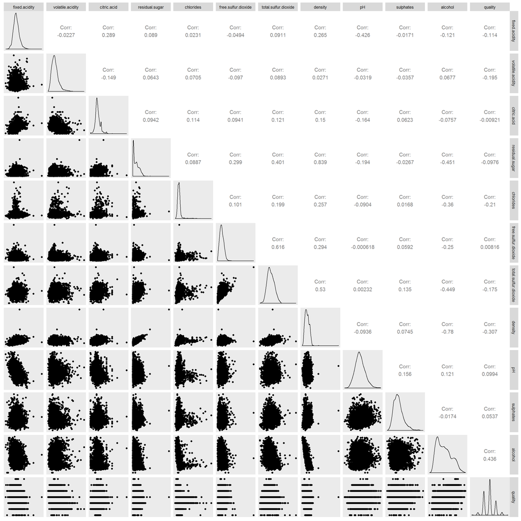

We get a fair idea of the relationships from the scatterplot matrix but it would be useful to go into the Pearson correlation coefficients for the variables excluding quality It does not make sense to include the ‘X’ variable which is the index, when we want to look at correlations. Since quality is a categorical ordinal variable, the Spearman correlationcoefficient should be calculated.

So I am using the dataframe excluding X and quality to look at Pearson coefficients. Let us generate a correlation matrix to get a visual idea about the strength of the relationships

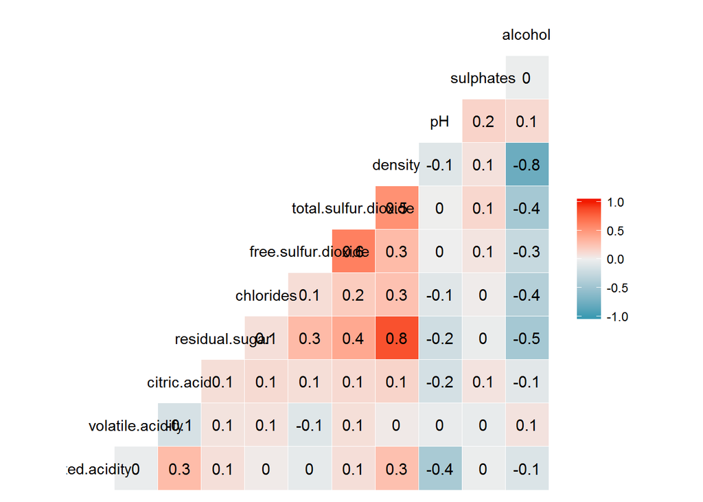

Let’s look closely at the correlation coefficicents from the above visual

The values that are greater than |0.3| are interpreted to be more meaningful as they signify a moderate/strong relationship

We see some moderate and some strong relationships from the visual above:

- Fixed acidity and pH have a moderate negative correlation, which can be reasoned out as pH value decreases with increasing acidity
- Residual sugar has a strong positive correlation with density which makes sense as more sugar makes the wine denser
- Free and total sulphur dioxide have a strong positive relationship which is expected, because total sulphur dioxide is the sum of free and bound sulphurdioxide
- Alcohol and density have a strong negative relationship suggesting that higher alcohol content results in lesser wine density . Alcohol is less dense than water, so this relationship seems to make sense

Let’s plot the moderate correlations

Fixed acidity vs pH

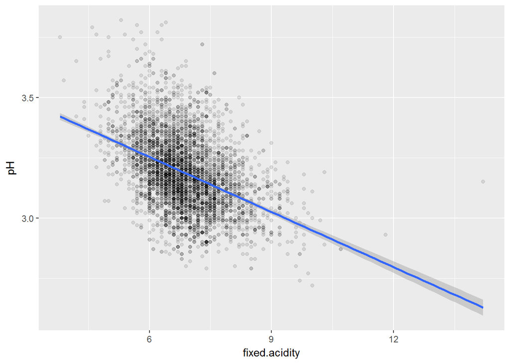

Free Sulphur dioxide vs Total sulphur dioxide

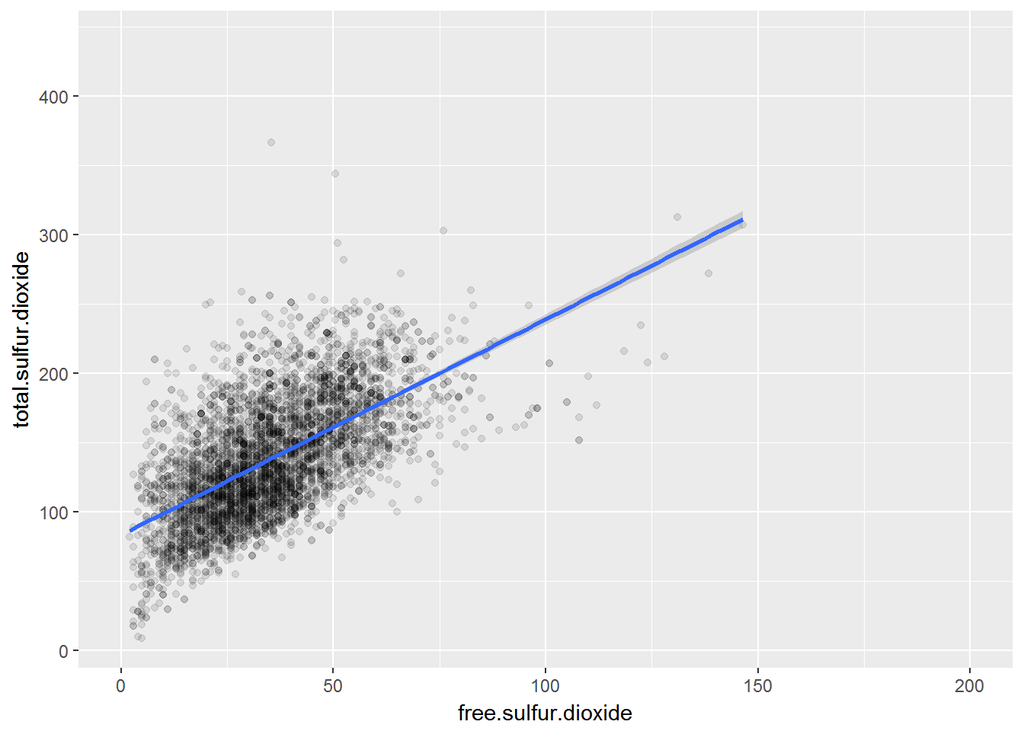

Let us visualize the strong relationships:

Residual sugar vs density

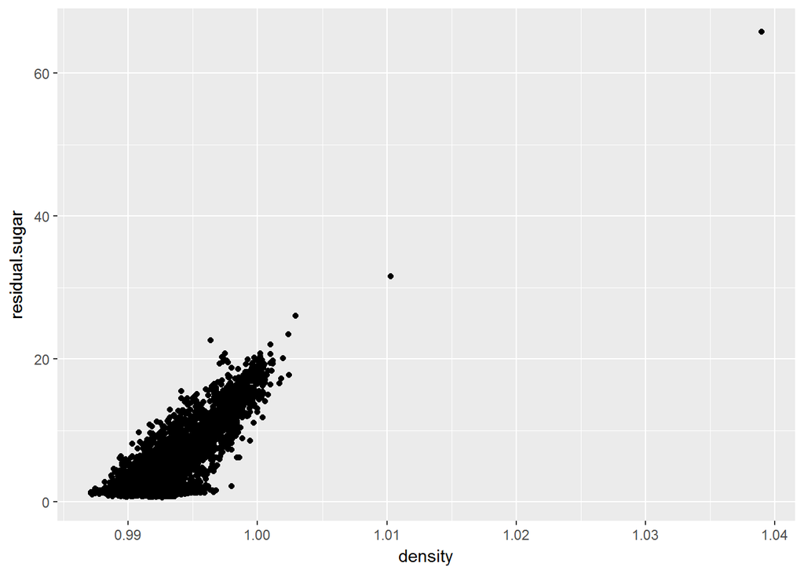

Let’s limit the axis to exclude outliers, reduce overplotting and look at the plot with a linear trendline

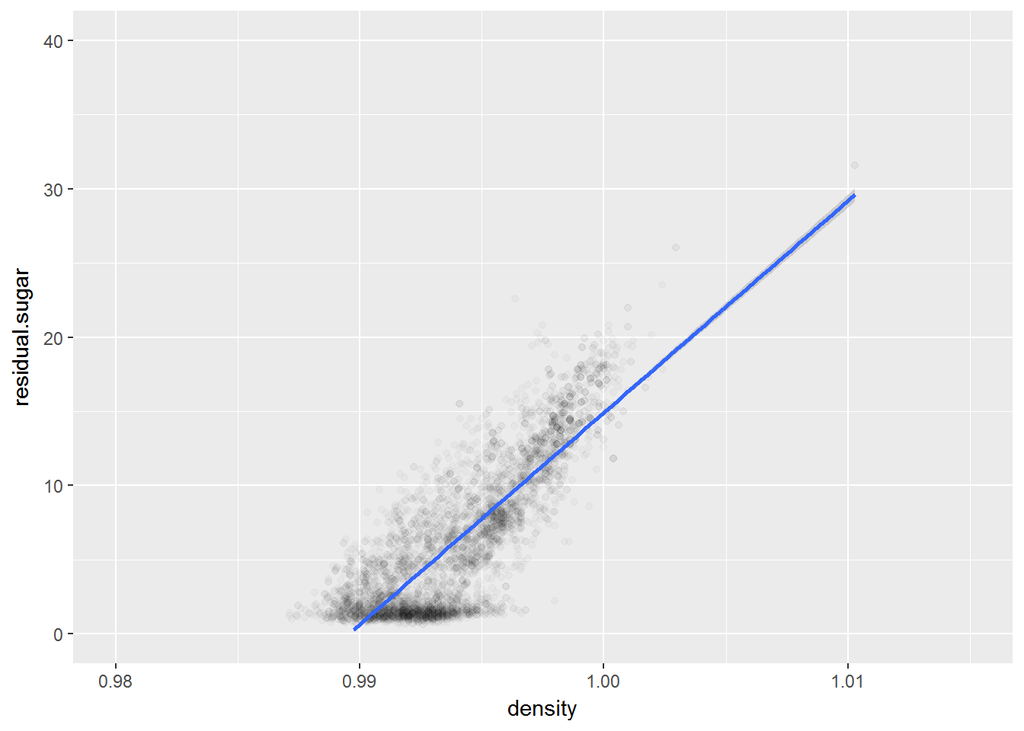

Let us visualize the relationship between alcohol and density

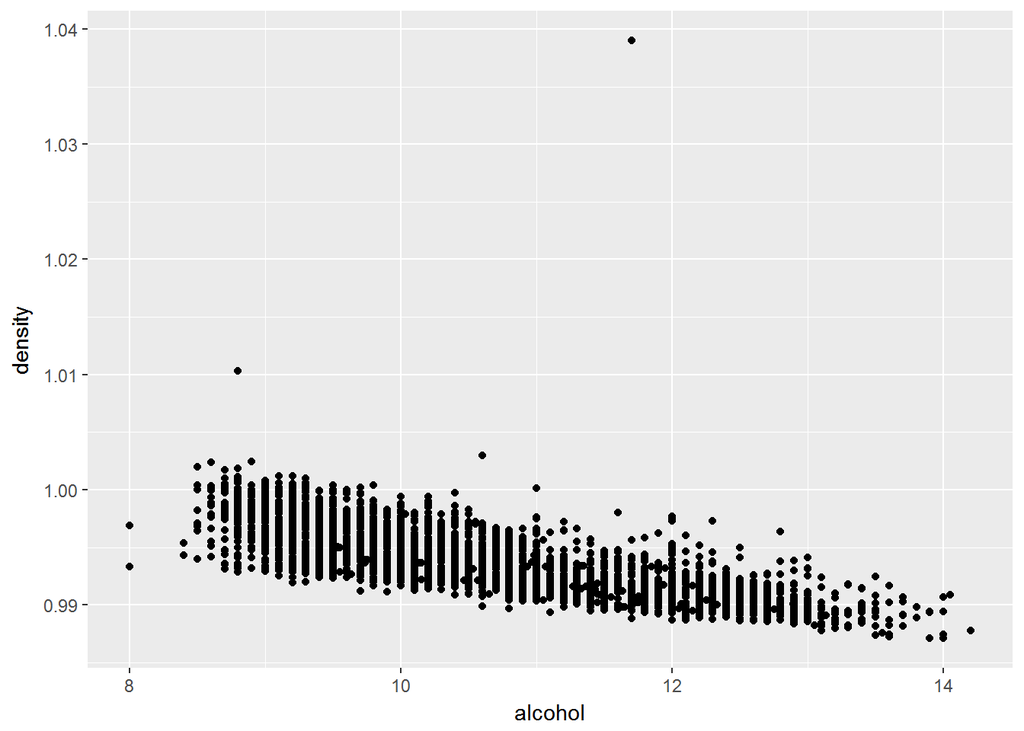

Let’s reduce overplotting and look at the plot again with a linear trendline, excluding two outliers

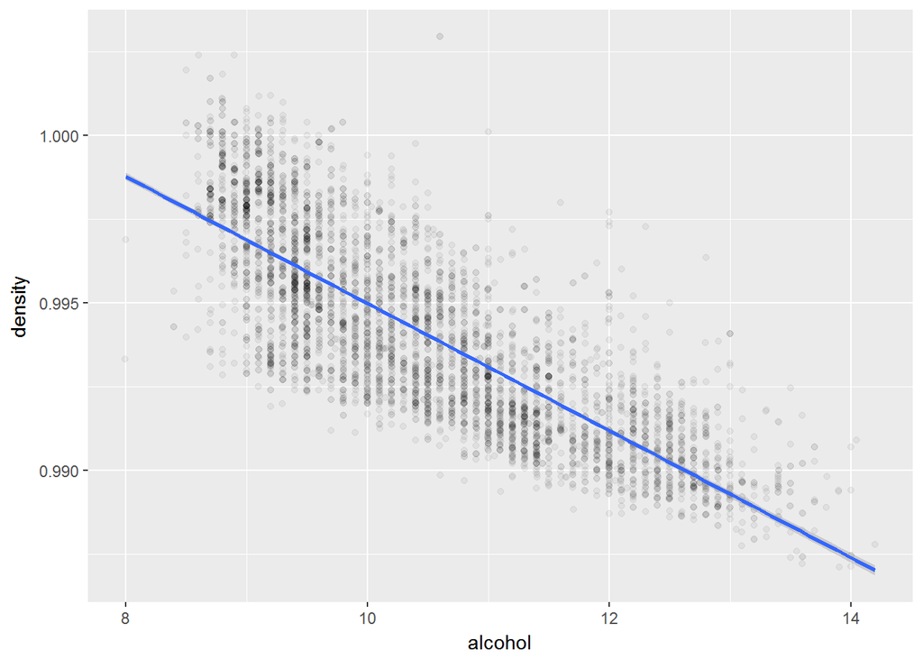

#### Spearman’s correlation coefficients for quality with other variables

Spearman’s correlation is generally used when ordinal variables are invloved. In this case we want to correlate continuous variables with an ordinal variable. For the purpose of this course, I have used Spearman’s coefficient but there could be more complex but more suited methods to accomplish this. The following are the Spearman correlation coefficients for all variables with quality:

```
##        fixed.acidity     volatile.acidity          citric.acid
##          -0.08448545          -0.19656168           0.01833273
##       residual.sugar            chlorides  free.sulfur.dioxide
##          -0.08206979          -0.31448848           0.02371338
## total.sulfur.dioxide              density                   pH
##          -0.19668029          -0.34835102           0.10936208
##            sulphates              alcohol              quality
##           0.03331897           0.44036918           1.00000000
```

From the above values we find that - Quality and Chlorides are moderately negatively correlated - Quality and density are moderately negatively correlated - Quality and alcohol are positively correlated

### Creating new variables

Discrete Quality Variable

It would be helpful to create a discrete quality variable and view the summary

```
##    3    4    5    6    7    8    9
##   20  163 1457 2198  880  175    5
```

Quality Bucket Variable

Let’s also create a quality bucket variable

Summary of quality variable

```
##    Min. 1st Qu.  Median    Mean 3rd Qu.    Max.
##   3.000   5.000   6.000   5.878   6.000   9.000
```

Summary of quality buckets:

```
##      low moderate     high
##      183     4535      180
```

Residual sugar bucket variable

Summary statistics for residual sugar

```
##    Min. 1st Qu.  Median    Mean 3rd Qu.    Max.
##   0.600   1.700   5.200   6.391   9.900  65.800
```

Let’s create a residual.sugar.bucket variable and view the summary

```
##    Low Medium   High
##   1500   1604   1794
```

Alcohol Bucket Variable

Let’s create an alcohol.bucket variable

Summary Statistics for the alcohol bucket variable:

```
##      low moderate     high
##     1436     2751      711
```

Density Bucket Variable

Summary of density

```
##    Min. 1st Qu.  Median    Mean 3rd Qu.    Max.
##  0.9871  0.9917  0.9937  0.9940  0.9961  1.0390
```

Let’s create a density.bucket variable

```
##    low medium   high
##   1446   1939   1513
```

#### Quality vs Chloride

Let’s plot discrete quality ratings and chloride values to visualize the relationship

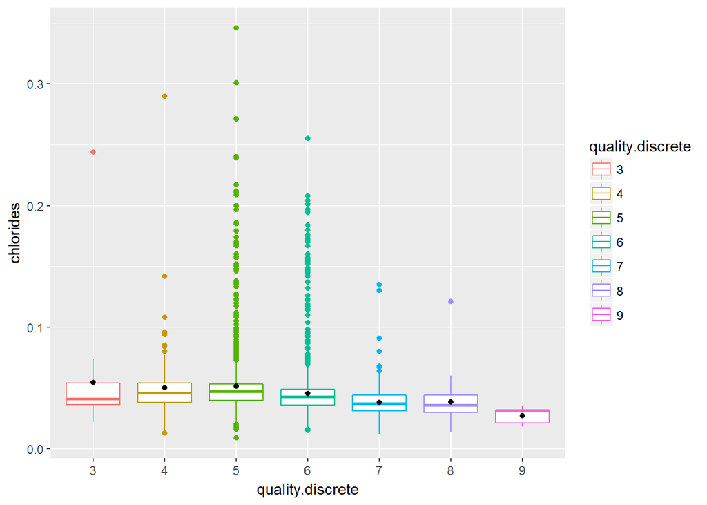

The relationship is not too clear from the box plot. However, the mean Chloride values for the high quality wines are slightly lesser than the lower quality wines

#### Quality vs Density

Let’s look at the boxplot of density vs quality, excluding some density outliers

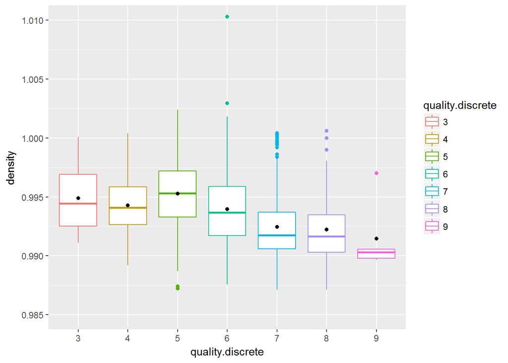

Summary statistics for wine density

```
##    Min. 1st Qu.  Median    Mean 3rd Qu.    Max.
##  0.9871  0.9917  0.9937  0.9940  0.9961  1.0390
```

Results for density statistics by quality level:

```
## quality: 3
##    Min. 1st Qu.  Median    Mean 3rd Qu.    Max.
##  0.9911  0.9925  0.9944  0.9949  0.9969  1.0001
## --------------------------------------------------------
## quality: 4
##    Min. 1st Qu.  Median    Mean 3rd Qu.    Max.
##  0.9892  0.9926  0.9941  0.9943  0.9958  1.0004
## --------------------------------------------------------
## quality: 5
##    Min. 1st Qu.  Median    Mean 3rd Qu.    Max.
##  0.9872  0.9933  0.9953  0.9953  0.9972  1.0024
## --------------------------------------------------------
## quality: 6
##    Min. 1st Qu.  Median    Mean 3rd Qu.    Max.
##  0.9876  0.9917  0.9937  0.9940  0.9959  1.0390
## --------------------------------------------------------
## quality: 7
##    Min. 1st Qu.  Median    Mean 3rd Qu.    Max.
##  0.9871  0.9906  0.9918  0.9925  0.9937  1.0004
## --------------------------------------------------------
## quality: 8
##    Min. 1st Qu.  Median    Mean 3rd Qu.    Max.
##  0.9871  0.9903  0.9916  0.9922  0.9935  1.0006
## --------------------------------------------------------
## quality: 9
##    Min. 1st Qu.  Median    Mean 3rd Qu.    Max.
##  0.9897  0.9898  0.9903  0.9915  0.9906  0.9970
```

Summary statistics for density by quality.bucket:

```
## quality.bucket: low
##    Min. 1st Qu.  Median    Mean 3rd Qu.    Max.
##  0.9892  0.9926  0.9941  0.9943  0.9960  1.0004
## --------------------------------------------------------
## quality.bucket: moderate
##    Min. 1st Qu.  Median    Mean 3rd Qu.    Max.
##  0.9871  0.9918  0.9938  0.9941  0.9962  1.0390
## --------------------------------------------------------
## quality.bucket: high
##    Min. 1st Qu.  Median    Mean 3rd Qu.    Max.
##  0.9871  0.9903  0.9916  0.9922  0.9935  1.0006
```

Summary statistics for density bucket by quality bucket:

```
## quality.bucket: low
##    low medium   high
##     35     94     54
## --------------------------------------------------------
## quality.bucket: moderate
##    low medium   high
##   1305   1792   1438
## --------------------------------------------------------
## quality.bucket: high
##    low medium   high
##    106     53     21
```

About 90% of high quality wines fall in the low and medium density buckets (60% - low density and 30% - medium density bucket) Only about 10% of high quality wines have high density. In general, we see that the mean density for high quality wines is lesser than that of low quality wines

#### Quality vs Alcohol

Let’s look at the boxplot of alcohol vs quality

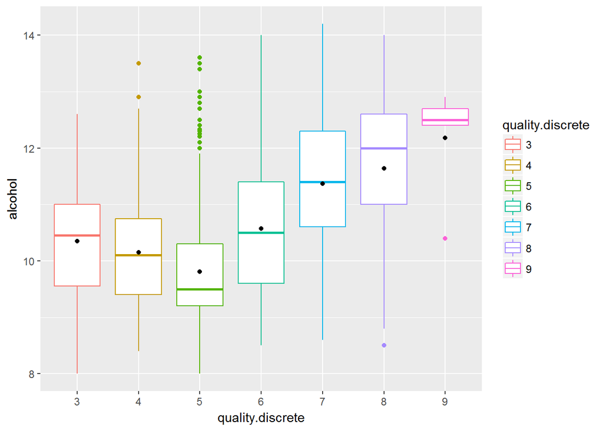

It’s interesting to see a clear trend of increasing alcohol content as the quality of wine gets better.

Summary Statistics for Alcohol bucket variable

```
##    Min. 1st Qu.  Median    Mean 3rd Qu.    Max.
##    8.00    9.50   10.40   10.51   11.40   14.20
```

```
##      low moderate     high
##      183     4535      180
```

```
##    Mode   FALSE    TRUE
## logical      34     146
```

More than 80% of high quality wines have alcohol content greater than the mean alcohol content in wines

Summary Statistics for Alcohol bucket by Quality bucket

```
## quality.bucket: low
##      low moderate     high
##       61      112       10
## --------------------------------------------------------
## quality.bucket: moderate
##      low moderate     high
##     1357     2564      614
## --------------------------------------------------------
## quality.bucket: high
##      low moderate     high
##       18       75       87
```

Only 5% of low quality wines have high alcohol content, while about 50% of high quality wines have high alcohol content

### Bivariate Analysis

#### Talk about some of the relationships you observed in this part of the investigation.How did the feature(s) of interest vary with other features ?

From the bivariate exploration, it was seen that quality, which is the main feature of interest did not strongly correlate with any of the variables. Alcohol level, density and chlorides seemed to correlate moderately with quality.

#### Did you observe any interesting relationships between the other features (not the main feature(s) of interest)?

Though quality did not directly correlate strongly with the variables, alcohol level vs density and residual sugar vs density are strong relationships. Fixed acidity acidity correlated negatively with pH which makes sense from knowledge of general chemistry

High quality wines seem to have high alcohol content and low density

#### What was the strongest relationship you found?

- Density vs residual sugar (0.8)
- Density vs alcohol (-0.8)

### Multivariate Exploration

Let’s pick the strongest relationships we saw in bivariate analysis and add a third variable to the plots

I’m curious about residual sugar since it is a parameter that can affect taste distinctly. So in the plot of density vs residual sugar, let us see how adding information on the quality bucket helps us understand the relationship The outliers for density have been excluded